# IMF Online Course: Macroeconomic forecasting

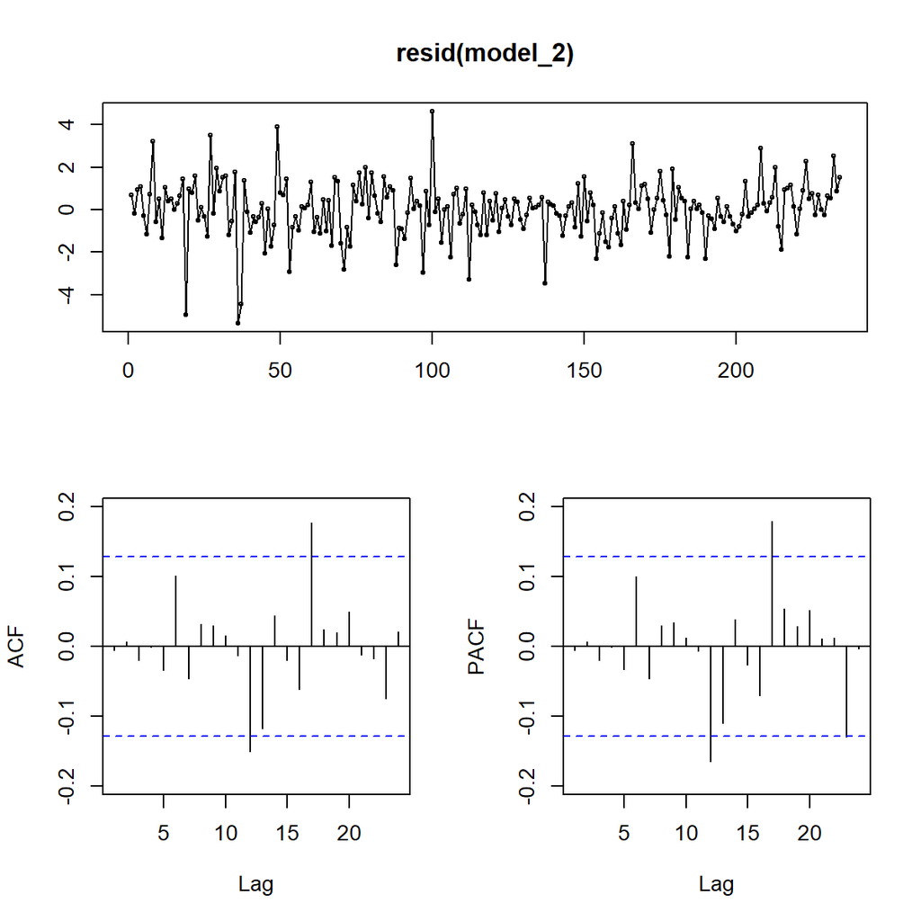

```r
# ar6
model_2 <-
  Arima(my_ts, c(6, 0, 0))

tsdisplay(resid(model_2))
```

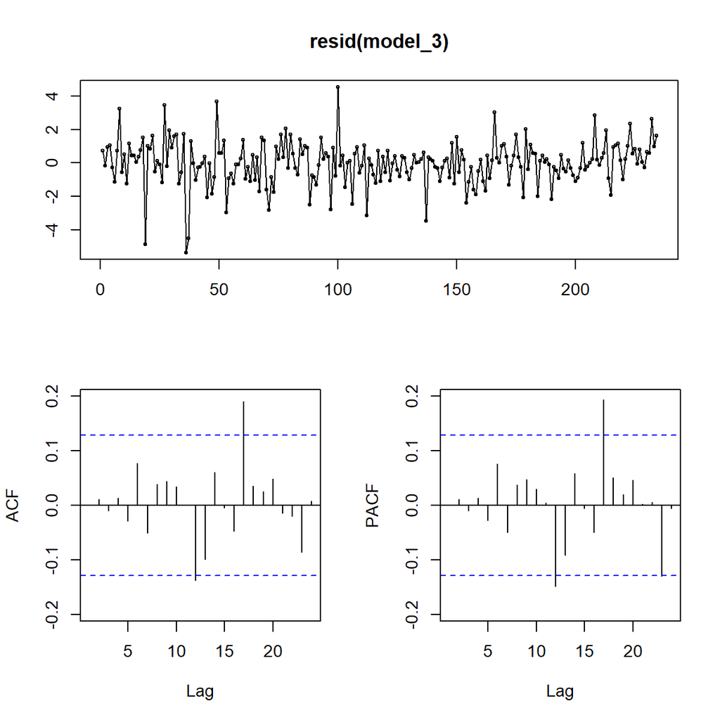

```r
# arma 6, 1
model_3 <-
  Arima(my_ts, c(6, 0, 1))

tsdisplay(resid(model_3))
```

### Working with Real World Data

Open `PE_ratios` and work with time series `pe_ind` (the stock market price-earnings ratio for India).

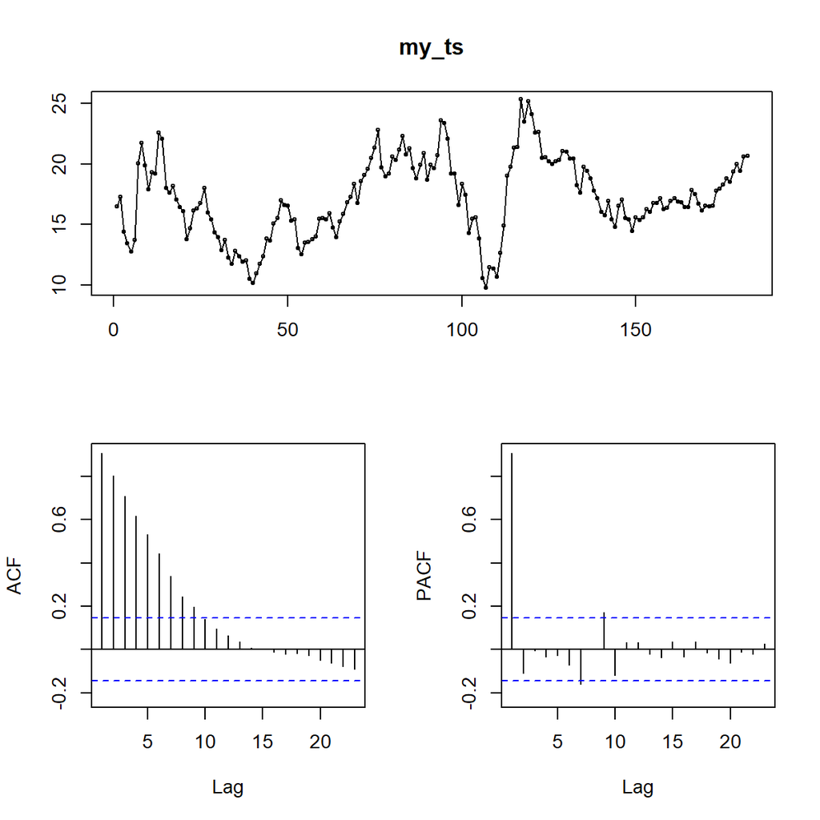

```r
my_pe <-
  my_df %>%
  select(date, pe_ind) %>%
  filter(complete.cases(.)) %>%
  mutate(date = as.Date(date))

# my time series
my_ts <- my_pe$pe_ind

# correlogram
tsdisplay(my_ts)
```

#### QUESTION 3.32

After viewing the ACF and PACF, which of the following statistical processes appears to be more likely? Select only one option.

The more likely is the AR statistical process.

### Automatic ARIMA Forecasting for Indian Price-to-Earnings

With series pe_ind (`my_ts`) run `Automatic ARIMA Forecasting`.

Specification:

- Transformation: None
- Max differencing: 0
- Max AR and Max MA: 6
- Max SAR and SMA: 0

Options:

- Model Selection?Akaike Information Criterion
- Eviews: Check the boxes for ARMA Criteria Table, ARMA Criteria Graph, Equation Output Table.

#### QUESTION 3.33

Which model was chosen?

```r
model_aic <-
  auto.arima(my_ts, # my time series
           stationary = TRUE, # restrict search to stationary models
           d = 0, # differences
           D = 0, # seasonal differences
           max.p = 6, # max AR terms
           max.q = 6, # max MA terms
           max.P = 0, # max SAR terms
           max.Q = 0, # max SMA terms
           trace = TRUE, # show models as estimated
           stepwise = FALSE)
```

```
 Fitting models using approximations to speed things up...

 ARIMA(0,0,0) with zero mean     : 1559.92
 ARIMA(0,0,0) with non-zero mean : 944.6179
 ARIMA(0,0,1) with zero mean     : 1332.964
 ARIMA(0,0,1) with non-zero mean : 785.308
 ARIMA(0,0,2) with zero mean     : 1166.433
 ARIMA(0,0,2) with non-zero mean : 711.1329
 ARIMA(0,0,3) with zero mean     : 1068.395
 ARIMA(0,0,3) with non-zero mean : 673.2821
 ARIMA(0,0,4) with zero mean     : 983.2497
 ARIMA(0,0,4) with non-zero mean : 657.6776
 ARIMA(0,0,5) with zero mean     : 933.3215
 ARIMA(0,0,5) with non-zero mean : 657.1584
 ARIMA(1,0,0) with zero mean     : Inf
 ARIMA(1,0,0) with non-zero mean : 627.5757
 ARIMA(1,0,1) with zero mean     : Inf
 ARIMA(1,0,1) with non-zero mean : 627.4597
 ARIMA(1,0,2) with zero mean     : Inf
 ARIMA(1,0,2) with non-zero mean : 629.5278
 ARIMA(1,0,3) with zero mean     : Inf
 ARIMA(1,0,3) with non-zero mean : 631.62
 ARIMA(1,0,4) with zero mean     : Inf
 ARIMA(1,0,4) with non-zero mean : 633.7489
 ARIMA(2,0,0) with zero mean     : Inf
 ARIMA(2,0,0) with non-zero mean : 628.1534
 ARIMA(2,0,1) with zero mean     : Inf
 ARIMA(2,0,1) with non-zero mean : 629.8776
 ARIMA(2,0,2) with zero mean     : Inf
 ARIMA(2,0,2) with non-zero mean : 631.3907
 ARIMA(2,0,3) with zero mean     : Inf
 ARIMA(2,0,3) with non-zero mean : 633.5284
 ARIMA(3,0,0) with zero mean     : Inf
 ARIMA(3,0,0) with non-zero mean : 626.2211
 ARIMA(3,0,1) with zero mean     : Inf
 ARIMA(3,0,1) with non-zero mean : 627.7017
 ARIMA(3,0,2) with zero mean     : Inf
 ARIMA(3,0,2) with non-zero mean : 620.1361
 ARIMA(4,0,0) with zero mean     : Inf
 ARIMA(4,0,0) with non-zero mean : 628.7091
```

[output cut: 40 more lines]

```
 ARIMA(3,0,1) with non-zero mean : 631.2299
 ARIMA(3,0,2) with zero mean     : Inf
 ARIMA(3,0,2) with non-zero mean : Inf
 ARIMA(4,0,0) with zero mean     : Inf
 ARIMA(4,0,0) with non-zero mean : 632.4043
 ARIMA(4,0,1) with zero mean     : Inf
 ARIMA(4,0,1) with non-zero mean : Inf
 ARIMA(5,0,0) with zero mean     : Inf
 ARIMA(5,0,0) with non-zero mean : 634.396





 Best model: ARIMA(2,0,0) with non-zero mean
```

```r
model_bic <-
  auto.arima(my_ts, # my time series
           stationary = TRUE, # restrict search to stationary models
           d = 0, # differences
           D = 0, # seasonal differences
           max.p = 6, # max AR terms
           max.q = 6, # max MA terms
           max.P = 0, # max SAR terms
           max.Q = 0, # max SMA terms
           trace = TRUE, # show models as estimated
           stepwise = FALSE,
           ic = "bic")
```

```
 Fitting models using approximations to speed things up...

 ARIMA(0,0,0) with zero mean     : 1563.102
 ARIMA(0,0,0) with non-zero mean : 950.9588
 ARIMA(0,0,1) with zero mean     : 1339.304
 ARIMA(0,0,1) with non-zero mean : 794.7851
 ARIMA(0,0,2) with zero mean     : 1175.911
 ARIMA(0,0,2) with non-zero mean : 723.7229
 ARIMA(0,0,3) with zero mean     : 1080.985
 ARIMA(0,0,3) with non-zero mean : 688.9613
 ARIMA(0,0,4) with zero mean     : 998.9288
 ARIMA(0,0,4) with non-zero mean : 676.4217
 ARIMA(0,0,5) with zero mean     : 952.0656
 ARIMA(0,0,5) with non-zero mean : 678.9428
 ARIMA(1,0,0) with zero mean     : Inf
 ARIMA(1,0,0) with non-zero mean : 637.0529
 ARIMA(1,0,1) with zero mean     : Inf
 ARIMA(1,0,1) with non-zero mean : 640.0498
 ARIMA(1,0,2) with zero mean     : Inf
 ARIMA(1,0,2) with non-zero mean : 645.2069
 ARIMA(1,0,3) with zero mean     : Inf
 ARIMA(1,0,3) with non-zero mean : 650.364
 ARIMA(1,0,4) with zero mean     : Inf
 ARIMA(1,0,4) with non-zero mean : 655.5332
 ARIMA(2,0,0) with zero mean     : Inf
 ARIMA(2,0,0) with non-zero mean : 640.7434
 ARIMA(2,0,1) with zero mean     : Inf
 ARIMA(2,0,1) with non-zero mean : 645.5567
 ARIMA(2,0,2) with zero mean     : Inf
 ARIMA(2,0,2) with non-zero mean : 650.1347
 ARIMA(2,0,3) with zero mean     : Inf
 ARIMA(2,0,3) with non-zero mean : 655.3127
 ARIMA(3,0,0) with zero mean     : Inf
 ARIMA(3,0,0) with non-zero mean : 641.9002
 ARIMA(3,0,1) with zero mean     : Inf
 ARIMA(3,0,1) with non-zero mean : 646.4458
 ARIMA(3,0,2) with zero mean     : Inf
 ARIMA(3,0,2) with non-zero mean : 641.9205
 ARIMA(4,0,0) with zero mean     : Inf
 ARIMA(4,0,0) with non-zero mean : 647.4532
 ARIMA(4,0,1) with zero mean     : Inf
 ARIMA(4,0,1) with non-zero mean : 651.0587
 ARIMA(5,0,0) with zero mean     : Inf
 ARIMA(5,0,0) with non-zero mean : 652.9668

 Now re-fitting the best model(s) without approximations...




 Best model: ARIMA(1,0,0) with non-zero mean
```

According to AIC selection criterion the higher order ARMA model was selected.

```r
model_aic
```

```
Series: my_ts
ARIMA(2,0,0) with non-zero mean

Coefficients:
         ar1      ar2     mean
      1.0085  -0.1104  17.2885
s.e.  0.0734   0.0736   0.9249

sigma^2 estimated as 1.779:  log likelihood=-310.02
AIC=628.04   AICc=628.27   BIC=640.86
```

#### QUESTION 3.34

Which model would be chosen on the basis of the the (Schwarz Info. Criteria) SIC?

*Hint: Run the same Automatic ARIMA forecasting proc and change the Model selection criteria (under options) from Akaike Info. Criteria to Schwarz Info. Criteria while keeping the other options as in Q3.33.*

According to BIC selection criterion the AR(1) model was selected.

```r
model_bic
```

```
Series: my_ts
ARIMA(1,0,0) with non-zero mean

Coefficients:
         ar1     mean
      0.9079  17.3197
s.e.  0.0300   1.0186

sigma^2 estimated as 1.791:  log likelihood=-311.14
AIC=628.28   AICc=628.41   BIC=637.89
```

### The Best Model?

In the assessments for Session 5, we suggested that a model with an AR(1) and a single MA term at lag 8 might outperform the three models we had observed. Run this model, which we will call Model 4 (note that the Automatic ARIMA Modeling would not consider such a model, as it would include all lags up to lag 8 not just the 8th lag and no other MA term). The results for the previous models are summarized below:

```r
# Model 1
model_1 <-
  Arima(my_ts, order = c(1, 0, 0))

# Model 2
my_ar_terms <- c(NA, rep(0, 6), NA)
my_ma_terms <- c(rep(0, 7), NA)
my_intercept <- NA

my_terms_mod_2 <-
  c(my_ar_terms, my_intercept)

model_2 <-
  Arima(my_ts, order = c(8, 0, 0), fixed = my_terms_mod_2)

# Model 3
my_terms_mod_3 <-
  c(my_ar_terms, my_ma_terms, my_intercept)

model_3 <-
  Arima(my_ts, order = c(8, 0, 8), fixed = my_terms_mod_3)

# Model 4
my_terms_mod_4 <-
  c(my_ar_terms[1], my_ma_terms, my_intercept)

model_4 <-
  Arima(my_ts, order = c(1, 0, 8), fixed = my_terms_mod_4)

my_models <- list(model_1, model_2, model_3, model_4)
```

#### QUESTION 3.35

Could Model 4 be considered the ?best??

```r
my_mod_df <-
  sapply(my_models, glance) %>%
  as.data.frame

names(my_mod_df) <- paste0("model_", 1:4)

my_mod_df
```

```
         model_1  model_2   model_3   model_4
sigma   1.338245 1.322589  1.293506  1.295974
logLik -311.1381 -308.571 -304.2476 -305.0698
AIC     628.2762  625.142  618.4953  618.1396
BIC     637.8882  637.958  634.5153  630.9556
nobs         182      182       182       182
```

Yes, according to AIC and BIC info criterion the best model is the last one.